# SEA-AD phenotype landscape: pathology, cognition, APOE, regional tissue state and glial molecular state

Five composite figures that establish what the cohort can and cannot support for the AD-resilience study

## Motivation

The study asks whether donors with comparable Alzheimer’s pathology differ in cognition, and whether regional tissue state and glial molecular state help to explain that difference. Before any morphology is added, this notebook establishes five preliminary observations.

1. Does SEA-AD contain pathology–cognition discordance at all?
2. Does APOE shift pathology, cognition at comparable pathology, or both?
3. In which regions do donors with comparable local pathology differ in cognition?
4. How do regional pathology and tissue response vary with stage?
5. Do the two carried-forward molecular-state variables track stage, cognition, or neither?

Everything here is descriptive and cross-sectional. The residual used below is an **exploratory phenotype**, not a validated measure of resilience. No association here is causal, and no ROI or signature is excluded or reselected because of it.

Inputs are reused unchanged:

- QNP P/H block: `qnp_primary_long()` from notebook 00, Grey matter only.
- Molecular state: the competitive scores in `molecular_state_analysis_table.csv` from notebook 03.
- Donor metadata and SpecimenMetadata.csv: the sources pinned in notebook 00.

Nothing was downloaded, rescored or re-aggregated.

## Figure 1: the pathology–cognition landscape

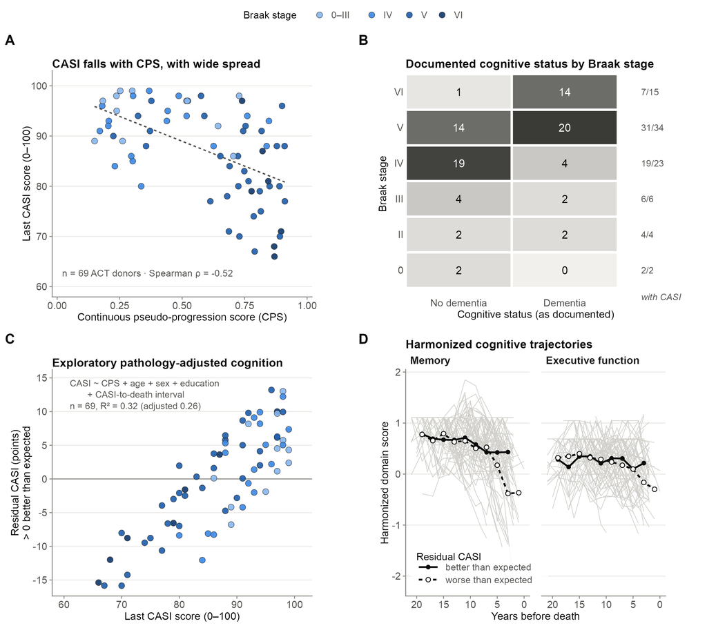

**Figure 1.** Pathology–cognition landscape. **A** Last CASI against the canonical CPS for the 69 ACT donors with CASI; dashed line is a descriptive least-squares fit. **B** Documented cognitive status by Braak stage for all 84 donors; right-hand column gives how many donors in each stage have CASI (CASI exists only for ACT, and Braak VI is under-represented in it). No donor is at Braak I. **C** Residual of the single baseline model against raw CASI. It is an exploratory phenotype, not a validated resilience measure. **D** Harmonized memory and executive-function scores for the same donors; grey lines are donors, black lines are 2-year-bin means shown where a bin holds at least five donors, split by the sign of the residual in C.

**Reading.** The ACT donors with CASI contain the discordance the study needs, within the restricted population described below. CASI falls with CPS (ρ = -0.52), but among the 38 donors with CPS above 0.6 it still spans 66 to 98. Among Braak V–VI donors, 15 of 49 have a documented status of no dementia. The baseline model explains R² = 0.32 of CASI, almost entirely through CPS. Age, sex, education and the assessment interval add little at this n.

The trajectories in D separate after baseline, not at it. First-visit memory, a median of 17 years before death, is unrelated to the residual (ρ = 0.06; first-visit executive function ρ = 0.00). Memory slope tracks it (ρ = 0.53), and executive-function slope less so (ρ = 0.27). Two things limit this reading:

- **The slope link is partly mechanical.** Slope and terminal CASI share the last assessments.
- **Baseline memory has a ceiling.** 23 of 69 donors sit at the maximum first-visit memory score (1.11), so baseline reserve is poorly resolved.

Biennial visits and whole-year ages also cannot distinguish slower decline from later-onset decline.

**Residual QC (no figure)**

- **Residual against CPS:** Spearman ρ = 0.02.
- **Residual against the CASI-to-death interval:** ρ = -0.01.
- **Mean residual by CPS tertile:** -1.1 / +2.2 / -1.0 points. The middle tertile sits high.
- **Quadratic CPS term:** adding it raises R² by 0.037 (F-test p = 0.07). It is not adopted, but the linear residual may carry some curvature in CPS.
- **Ceiling:** 18 of 69 donors score CASI ≥ 95, so the positive residual tail is truncated.
- **Cohort:** not in the model. All CASI donors are ACT, so it is constant.

### Who the CASI analyses represent

Selection into the CASI analyses. Descriptive only; no CASI value is imputed for ADRC donors, and documented dementia status is not converted into a CASI-like score.

| Variable | ACT (has CASI) | ADRC (no CASI) | All donors |
| --- | --- | --- | --- |
| Donors | 69 | 15 | 84 |
| CPS, median [IQR] | 0.65 [0.34–0.79] | 0.84 [0.75–0.91] | 0.71 [0.38–0.84] |
| Braak 0–III / IV / V / VI | 12 / 19 / 31 / 7 | 0 / 4 / 3 / 8 | 12 / 23 / 34 / 15 |
| Documented dementia | 32/69 (46%) | 10/15 (67%) | 42/84 (50%) |
| Dementia among Braak V–VI | 25/38 (66%) | 9/11 (82%) | 34/49 (69%) |
| ε4 carrier | 17/69 (25%) | 8/15 (53%) | 25/84 (30%) |
| ε4/ε4 | 2/69 (3%) | 4/15 (27%) | 6/84 (7%) |
| Age at death, median [range] | 91 [72–102] | 82 [65–100] | 90 [65–102] |

The CASI analyses cover a restricted and systematically different part of the cohort. They are the ACT donors: older (median age at death 91 vs 82) and less advanced (median CPS 0.65 vs 0.84). No ADRC donor is at Braak 0–III, and 8 of the 15 Braak VI donors are ADRC.

The advanced, younger, ε4-enriched end of SEA-AD is therefore under-represented in every CASI panel: 8 of 25 ε4 carriers and 4 of 6 ε4/ε4 donors are ADRC. Figures 1A, 1C, 2C–D, 3 and the right column of Figure 5 describe pathology–cognition discordance in older ACT donors, mostly at Braak IV–V. They do not describe the full cohort.

## Figure 2: APOE and susceptibility, pathology and cognition

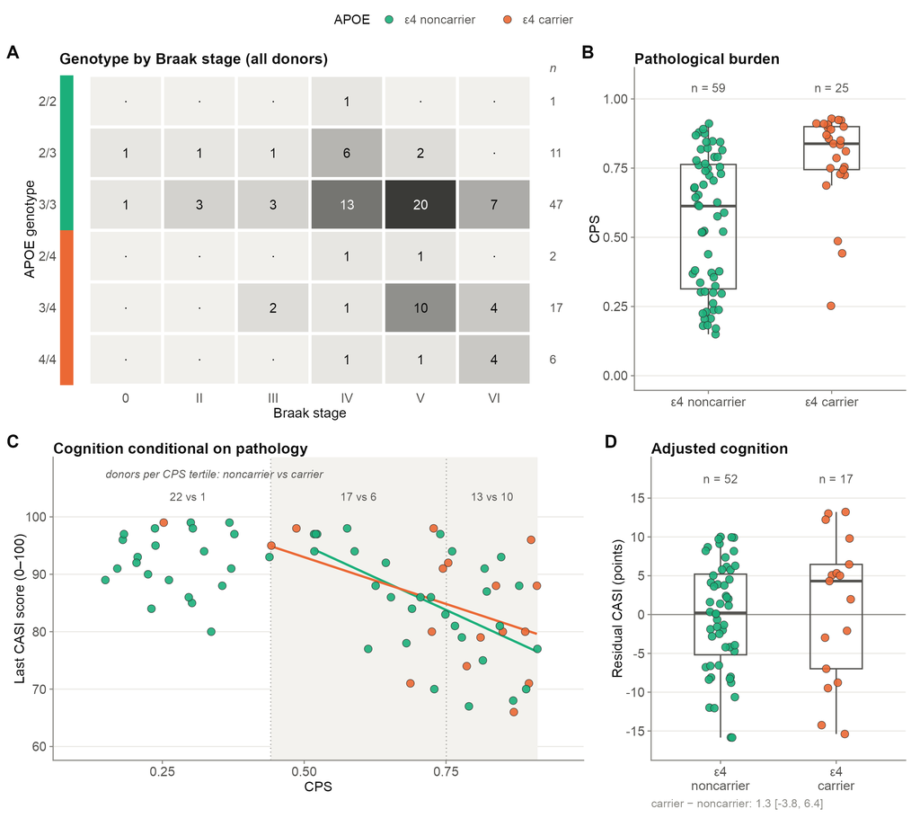

**Figure 2.** APOE and pathology and cognition. **A** Observed genotype by Braak stage for all 84 donors (source: `APOE Genotype`, no missing values); the coloured bar marks the ε4 grouping used in B–D, and ε2/ε4 (n = 2) is counted as a carrier. **B** CPS by ε4 carrier status, all donors. **C** Last CASI against CPS in the ACT donors with CASI. Dotted lines mark pooled CPS tertiles; the counts above them are noncarrier vs carrier donors per tertile; the shaded band and group lines cover only the tertiles where both groups have at least five donors. **D** Baseline-model residual (Figure 1C) by carrier status; caption gives the difference in means with Welch 95% CI.

**Reading.** APOE differences appear principally in pathology burden. ε4 carriers have higher CPS (median 0.84 vs 0.61, Wilcoxon p = 1.7e-05, descriptive). They are concentrated in Braak V–VI. The 6 ε4/ε4 donors have median CPS 0.91, and only 2 of them have CASI.

Carriers are almost absent from the lowest CPS tertile, so cognition can be compared at comparable pathology only across the middle and upper tertiles. Within that range the carrier and noncarrier trends overlap. The adjusted-cognition difference is small and uncertain:

- **All carriers:** 1.3 [-3.8, 6.4] points.
- **Excluding ε2/ε4:** 0.2 [-5.3, 5.6].
- **Within the shared CPS range:** 0.3 [-5.5, 6.0].

There is therefore no evidence here for an APOE association with cognition conditional on pathology. There is also no power to exclude one, and nothing here bears on protection.

**Selection affects this comparison.** The CPS difference is not an artefact of pooling cohorts: within ACT alone, carriers still have higher CPS (median 0.79 vs 0.55). The cognition comparison (C–D), however, loses 8 of the 25 carriers and 4 of the 6 ε4/ε4 donors, all ADRC and all without CASI. It therefore concerns mainly ε3/ε4 donors surviving to old age in ACT.

## Figure 3: is regional resilience identifiable?

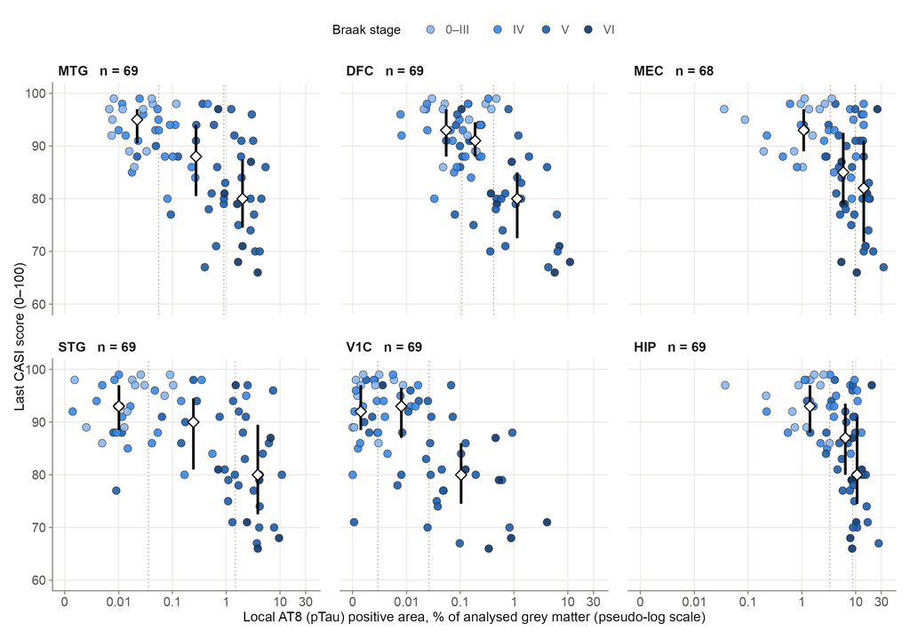

**Figure 3.** Local pTau against terminal cognition in the six candidate ROIs. Each point is one ACT donor with CASI and a Grey matter AT8 value in that ROI; facets are independent donor sets of the stated size. Dotted lines divide each ROI into tertiles of local AT8, and white diamonds with bars give the CASI median and interquartile range within each tertile. Tertiles span wide burden ranges, so this shows broad spread at similar local burden, not matched pathology; the comparable-burden check below pairs donors on CPS and local AT8 jointly. No regression is drawn. The x-axis is pseudo-log (linear within ±0.001%) so that true zeros stay visible; tick labels are in % area.

Regional feasibility. Complete = ACT donors with CASI and a local AT8 value. Tertiles are within ROI, the same bins as in Figure 3; a tertile is a wide burden band, not a matched set. MG4/Astro coverage counts those donors who also have both competitive molecular-state scores.

| ROI | Complete donors | Braak coverage (0–III / IV / V / VI) | Local pTau, % area (P10–P90) | Spearman ρ, AT8 vs CASI | Broad spread (CASI IQR by AT8 tertile, low / mid / high; top-tertile range) | MG4/Astro coverage | Reading |
| --- | --- | --- | --- | --- | --- | --- | --- |
| MTG | 69 | 12 / 19 / 31 / 7 | 0.013–3 (median 0.27) | -0.57 | IQR 6 / 14 / 13; top tertile (≥ 0.91%) CASI 66–97 | 69/69 | Spread in the middle and upper AT8 tertiles; complete molecular coverage. |
| DFC | 69 | 12 / 19 / 31 / 7 | 0.032–2.3 (median 0.19) | -0.55 | IQR 9 / 6 / 12; top tertile (≥ 0.46%) CASI 66–99 | 66/69 | Spread mainly in the upper tertile; lower absolute pTau than MTG; near-complete molecular coverage. |
| MEC | 68 | 12 / 18 / 31 / 7 | 0.79–17 (median 5.7) | -0.45 | IQR 8 / 14 / 19; top tertile (≥ 9.9%) CASI 66–98 | 65/68 | Early-involved: pTau already > 1% in the lowest tertile, so all spread is at high burden; strongest NeuN change (Fig. 4). |
| STG | 69 | 12 / 19 / 31 / 7 | 0.0082–4.3 (median 0.25) | -0.49 | IQR 8 / 14 / 17; top tertile (≥ 1.5%) CASI 66–97 | 34/69 | Spread similar to MTG; molecular state for about half the donors. |
| V1C | 69 | 12 / 19 / 31 / 7 | 0.00039–0.36 (median 0.008) | -0.49 | IQR 8 / 10 / 12; top tertile (≥ 0.028%) CASI 66–97 | 34/69 | pTau near detection floor for most donors; spread appears only in the top tertile. Mainly a late-progression region. |
| HIP | 69 | 12 / 19 / 31 / 7 | 1.1–13 (median 6.4) | -0.49 | IQR 9 / 14 / 16; top tertile (≥ 8.8%) CASI 67–98 | 31/69 | Early-involved like MEC; spread at high burden; molecular state for about half the donors. |

**Comparable-burden check.** A wide CASI range inside an AT8 tertile is not the same as discordance at matched pathology. The tertiles span up to two orders of magnitude of AT8, and donors in the same tertile can differ widely in CPS. So each ROI is also checked on donor *pairs* that are close on both global and local burden.

- **Tolerances**, declared once and not varied:
  - |ΔCPS| ≤ 0.05;
  - local AT8 within a factor of 2, i.e. |Δlog₁₀(AT8 + 0.001)| ≤ 0.30;
  - local Aβ within a factor of 2 in the sensitivity column.
- **Elevated burden:** only pairs where both donors have CPS above the CASI-set median.
- **Discordant pair:** |ΔCASI| ≥ 10 points, about 1.3 residual SDs of the baseline model. This describes a difference; it is not a diagnostic cut-off.
- **Reference:** the median |ΔCASI| over *all* elevated-burden pairs, so matching can be seen to shrink the spread or not.
- **Reporting unit:** pairs share donors, so the table reports distinct donors, not pairs.

Comparable-burden check at elevated burden (CPS > 0.65, the CASI-set median). Matched = |ΔCPS| ≤ 0.05 and local AT8 within a factor of 2; discordant = |ΔCASI| ≥ 10 points. Counts are distinct donors.

| ROI | Elevated-burden donors | Donors with a matched partner | Median \|ΔCASI\|, matched (all elevated pairs) | Donors in a discordant matched pair | … also matched on Aβ | … both with MG4/Astro | Reading |
| --- | --- | --- | --- | --- | --- | --- | --- |
| MTG | 34 | 30 | 10.0 (9.0) | 24 | 20 | 24 | discordance observed at comparable CPS + local AT8; with molecular state: supported |
| DFC | 34 | 31 | 7.0 (9.0) | 18 | 10 | 16 | discordance observed at comparable CPS + local AT8; with molecular state: supported |
| MEC | 34 | 31 | 10.0 (9.0) | 29 | 25 | 26 | discordance observed at comparable CPS + local AT8; with molecular state: supported |
| STG | 34 | 30 | 9.0 (9.0) | 21 | 13 | 5 | discordance observed at comparable CPS + local AT8; with molecular state: limited |
| V1C | 34 | 29 | 8.0 (9.0) | 23 | 15 | 0 | discordance observed at comparable CPS + local AT8; with molecular state: insufficient |
| HIP | 34 | 33 | 9.0 (9.0) | 24 | 14 | 7 | discordance observed at comparable CPS + local AT8; with molecular state: limited |

**Reading.** The regional data establish three different things, and only the second is pathology-matched discordance.

1. **Broad spread at elevated pathology.** In the upper AT8 tertile, CASI spans 31 to 33 points in every ROI. On its own this is not matched pathology.
2. **Discordance at comparable measured burden.** At elevated burden, most donors have a partner within the declared CPS and local-AT8 tolerances, and matching narrows the spread little (most in DFC): median |ΔCASI| is 7–10 points matched vs 9 unmatched. 18–29 donors per ROI sit in a matched pair that differs by at least 10 CASI points. This survives matching on local Aβ as well (10–25 donors); DFC has the fewest.
3. **Insufficient support once molecular state is required.** A matched discordant pair with MG4 and astrocyte scores on both donors involves 24, 16 and 26 donors in MTG, DFC and MEC, but only 5, 7 and 0 in STG, HIP and V1C.

The matched spread does not show that the discordance is biological. Terminal CASI also carries test measurement error and a variable CASI-to-death interval, and the measured burden is grey-matter percent area in one sampled block per ROI.

None of these readings is a reason to drop a region from later morphology.

## Figure 4: pathology and tissue integrity across disease stage

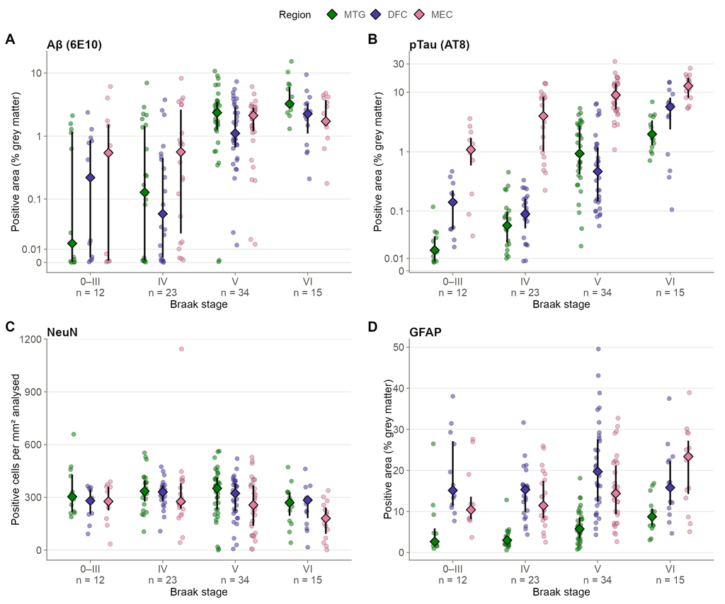

**Figure 4.** Grey matter QNP measures by Braak stage in MTG, DFC and MEC, all donors with a value (MTG 84, DFC 84, MEC 83). Small points are donors; diamonds with bars are the median and interquartile range for each region × stage. Each panel keeps its own units and scale; Aβ and pTau use a pseudo-log axis (linear within ±0.01%) with tick labels in % area. Braak 0–III pools 2, 4 and 6 donors at stages 0, II and III; no donor is at stage I. Cross-sectional stage groups are different donors, not trajectories. Absolute GFAP levels are not assumed comparable across regions.

**Reading.** The two pathologies follow different stage patterns:

- **Aβ** is already present in MEC at Braak 0–III, and rises most in the neocortex (MTG, DFC).
- **pTau** rises steeply in MEC from the earliest stages and reaches the neocortex mainly at Braak V–VI.
- **NeuN** is lower at Braak VI than at IV–V in all three regions, most clearly in MEC (median 180 vs 277 cells/mm² at Braak IV). NeuN varies widely within every stage, and correlates only weakly with local pTau in every region (ρ -0.24 to 0.29 across the 9 regions with NeuN).
- **GFAP** is heterogeneous rather than uniformly progressive. It rises through Braak VI in MTG (median 2.7 → 8.7%) and in MEC, but has no consistent stage trend in DFC (ρ with Braak 0.09).

So at a given stage, donors and regions differ in tissue response, which is the heterogeneity morphology is meant to explain.

**All regions: Spearman correlation of each QNP measure with Braak stage**

Grey matter, all donors with a value. NeuN and GFAP are not released for AnG or FI. The remaining ROIs show the same qualitative split as Figure 4 (pTau tracks stage more tightly than Aβ; NeuN barely tracks stage; GFAP tracks it only in some regions), so no second grid is drawn.

| Region | Donors | Aβ | pTau | NeuN | GFAP | NeuN vs local pTau | GFAP vs local pTau |
| --- | --- | --- | --- | --- | --- | --- | --- |
| AnG | 43 | 0.64 | 0.79 | – | – | – | – |
| CaH | 42 | 0.64 | 0.89 | 0.29 | -0.05 | 0.29 | -0.02 |
| DFC | 84 | 0.55 | 0.65 | -0.08 | 0.09 | -0.21 | 0.03 |
| ESOC | 84 | 0.54 | 0.77 | -0.04 | 0.06 | -0.16 | 0.02 |
| FI | 43 | 0.74 | 0.78 | – | – | – | – |
| HIP | 84 | 0.48 | 0.66 | -0.06 | 0.16 | -0.13 | 0.12 |
| ITG | 43 | 0.72 | 0.77 | -0.05 | 0.21 | -0.23 | 0.31 |
| MEC | 83 | 0.37 | 0.64 | -0.26 | 0.29 | -0.24 | 0.20 |
| MTG | 84 | 0.66 | 0.81 | -0.13 | 0.48 | -0.18 | 0.44 |
| STG | 84 | 0.59 | 0.75 | -0.03 | 0.27 | -0.06 | 0.20 |
| V1C | 84 | 0.59 | 0.77 | -0.04 | -0.00 | -0.14 | -0.03 |

## Figure 5: molecular state, disease response or cognition-related variation?

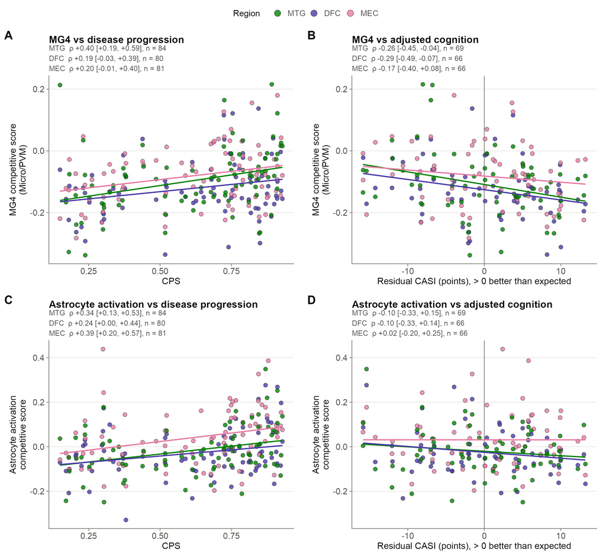

**Figure 5.** Competitive molecular-state scores (notebook 03: assay-adjusted, nucleus-weighted, matched-background corrected) in MTG, DFC and MEC against the canonical CPS (left) and against the exploratory adjusted cognition of Figure 1C (right; ACT donors only). Points are donor × ROI; lines are per-ROI least-squares fits, descriptive only. Estimates are within-ROI Spearman ρ with donor-bootstrap 95% CI (2000 resamples); within an ROI each donor appears once. Support: every plotted value is `well supported` (minimum 27 nuclei).

**Reading.** Both states track disease stage, and they relate to the other variables differently:

- **With stage:** both rise with CPS in all three ROIs. The mean within-ROI ρ is 0.26 [0.09, 0.43] for MG4 and 0.32 [0.13, 0.48] for astrocyte activation (donor-cluster bootstrap).
- **With local pathology:** MG4 tracks local AT8 more closely than CPS (ρ 0.29 to 0.42).
- **With adjusted cognition (descriptive, Figure 5 right column):** MG4 is modestly *lower* in donors with better-than-expected cognition, in the same direction in all three ROIs (mean ρ -0.24 [-0.40, -0.06]). Astrocyte activation shows no such relation (-0.06 [-0.25, 0.14]), and neither does the MG8 sensitivity variable.
- **With tissue injury:** astrocyte activation is the one that associates with lower NeuN density in all three ROIs; MG4 does not (table below).

APOE does not materially change either score at fixed CPS: every carrier contrast has a confidence interval that includes zero. No stratified panel was therefore added.

### Joint-model check

A correlation with a residual can mislead when the molecular state is itself correlated with a covariate the residual removed, as MG4 is with CPS. So each score is also entered directly into the baseline model, one ROI and one score at a time:

`CASI ~ CPS + age + sex + education + CASI-to-death interval + state`

Details of the fit:

- **Sample:** baseline and joint model are fitted on the identical donors (ACT donors with CASI and that score in that ROI).
- **Scaling:** the state is standardised within that sample, so the estimate is CASI points per SD.
- **No nonlinear terms:** the Figure 1 QC found only a marginal quadratic signal (ΔR² 0.037), which is not a material misspecification.
- **No interactions** are fitted.
- **Co-pathology column:** the right-hand columns repeat the fit with LATE-NC stage 2–3 and severe arteriolosclerosis added to both the baseline and the joint model (see the co-pathology section).

Joint adjusted models, one per ROI and score. Every row compares nested models on the identical donors. The state estimate is a pathology- and covariate-adjusted association, not an effect.

| Score | ROI | Donors | Baseline R² | State, CASI points per SD [95% CI] | ΔR² (Δ adjusted R²) | + LATE + arteriolosclerosis: state per SD | ΔR² over co-pathology baseline |
| --- | --- | --- | --- | --- | --- | --- | --- |
| MG4 | MTG | 69 | 0.32 | -2.4 [-4.3, -0.5] | +0.065 (+0.060) | -2.1 [-4.0, -0.3] | +0.048 |
| MG4 | DFC | 66 | 0.33 | -2.1 [-4.1, -0.2] | +0.050 (+0.043) | -1.8 [-3.7, 0.1] | +0.036 |
| MG4 | MEC | 66 | 0.27 | -1.4 [-3.5, 0.7] | +0.022 (+0.011) | -1.2 [-3.3, 0.9] | +0.015 |
| Astrocyte activation | MTG | 69 | 0.32 | -1.4 [-3.5, 0.7] | +0.018 (+0.008) | -1.2 [-3.2, 0.8] | +0.014 |
| Astrocyte activation | DFC | 66 | 0.33 | -1.6 [-3.6, 0.4] | +0.028 (+0.018) | -0.9 [-2.9, 1.1] | +0.008 |
| Astrocyte activation | MEC | 66 | 0.27 | -0.1 [-2.2, 2.0] | +0.000 (-0.013) | 0.5 [-1.6, 2.6] | +0.003 |

The descriptive residual correlation largely holds up in the joint model, but not uniformly:

- **MG4, MTG and DFC:** CASI is lower per SD of MG4, -2.4 [-4.3, -0.5] points in MTG and -2.1 [-4.1, -0.2] in DFC.
- **MG4, MEC:** -1.4 [-3.5, 0.7], which includes zero.
- **Astrocyte activation:** no estimate excludes zero in any ROI.
- **Size:** adding MG4 raises R² by only 0.022–0.065.

With LATE-NC and severe arteriolosclerosis added, the MG4 estimates become -2.1 [-4.0, -0.3] (MTG), -1.8 [-3.7, 0.1] (DFC) and -1.2 [-3.3, 0.9] (MEC). They stay negative but attenuate by 13–15%, and the interval now excludes zero only in MTG. These are small single-ROI models. In the separate local-AT8 sensitivity (supporting estimates below), the MG4 interval includes zero in DFC and MEC.

The estimates are pathology- and covariate-adjusted associations in older ACT donors. They say nothing about MG4 protecting or harming cognition, and they are not grounds to reselect either signature.

**Supporting estimates: tissue-injury associations, MG8 sensitivity and APOE**

Within-ROI Spearman ρ [donor-bootstrap 95% CI] of each competitive score against disease stage, local pathology, tissue measures and adjusted cognition. MG8 is the secondary Micro/PVM sensitivity variable.

| Score | ROI | CPS | Adjusted cognition | Local AT8 | NeuN | GFAP |
| --- | --- | --- | --- | --- | --- | --- |
| MG4 | MTG | +0.40 [+0.19, +0.59] | -0.26 [-0.45, -0.04] | +0.42 [+0.22, +0.59] | -0.10 [-0.32, +0.13] | +0.31 [+0.10, +0.51] |
| MG4 | DFC | +0.19 [-0.03, +0.39] | -0.29 [-0.49, -0.07] | +0.29 [+0.06, +0.47] | +0.02 [-0.20, +0.25] | +0.08 [-0.14, +0.29] |
| MG4 | MEC | +0.20 [-0.01, +0.40] | -0.17 [-0.40, +0.08] | +0.36 [+0.14, +0.56] | +0.06 [-0.18, +0.30] | +0.02 [-0.17, +0.23] |
| Astro | MTG | +0.34 [+0.13, +0.53] | -0.10 [-0.33, +0.15] | +0.15 [-0.07, +0.35] | -0.30 [-0.49, -0.08] | +0.20 [-0.02, +0.41] |
| Astro | DFC | +0.24 [+0.00, +0.44] | -0.10 [-0.33, +0.14] | +0.27 [+0.06, +0.47] | -0.33 [-0.52, -0.12] | +0.12 [-0.12, +0.34] |
| Astro | MEC | +0.39 [+0.20, +0.57] | +0.02 [-0.20, +0.25] | +0.17 [-0.04, +0.37] | -0.33 [-0.51, -0.14] | +0.19 [-0.02, +0.38] |
| MG8 | MTG | +0.33 [+0.13, +0.52] | -0.01 [-0.23, +0.19] | +0.22 [-0.01, +0.44] | -0.18 [-0.37, +0.04] | +0.25 [+0.00, +0.47] |
| MG8 | DFC | +0.19 [-0.01, +0.38] | +0.02 [-0.22, +0.25] | +0.08 [-0.13, +0.30] | -0.12 [-0.33, +0.11] | +0.05 [-0.17, +0.28] |
| MG8 | MEC | +0.29 [+0.07, +0.50] | +0.02 [-0.22, +0.27] | +0.14 [-0.10, +0.37] | -0.13 [-0.35, +0.12] | -0.06 [-0.27, +0.15] |

Sensitivity: the MG4–cognition association with local pTau added, and the APOE ε4 carrier contrast in each score at fixed CPS. Estimates with 95% CI from within-ROI linear models, one row per donor.

| ROI | n (ACT) | Adjusted cognition per SD of MG4, given local AT8 (points) | MG4 carrier − noncarrier, given CPS (SD) | Astro carrier − noncarrier, given CPS (SD) |
| --- | --- | --- | --- | --- |
| MTG | 69 | -1.9 [-3.7, -0.0] | -0.04 [-0.54, 0.46] | -0.15 [-0.66, 0.35] |
| DFC | 66 | -1.2 [-3.0, 0.7] | -0.46 [-1.00, 0.07] | -0.41 [-0.94, 0.13] |
| MEC | 65 | -0.7 [-2.7, 1.4] | -0.32 [-0.84, 0.21] | -0.25 [-0.77, 0.27] |

## Cohort and coverage

Cohort and coverage. Figures that pool ROIs never treat a donor’s ROIs as independent donors: per-ROI estimates use one row per donor, and the pooled Figure 5 estimate resamples donors.

[output not shown]

## Supporting check: co-pathology and APOE context

Co-pathology by phenotype. Residual groups are the 69 ACT donors with CASI; the Braak V–VI contrast uses documented cognitive status in all donors; APOE uses all donors. Counts are k/n with n the donors rated.

| Co-pathology | Residual > 0 (n = 38) | Residual ≤ 0 (n = 31) | Braak V–VI, no dementia (n = 15) | Braak V–VI, dementia (n = 34) | ε4 noncarrier (n = 59) | ε4 carrier (n = 25) |
| --- | --- | --- | --- | --- | --- | --- |
| LATE-NC stage 2–3 | 13/38 (34%) | 19/31 (61%) | 7/15 (47%) | 24/33 (73%) | 28/58 (48%) | 13/25 (52%) |
| Lewy body disease, limbic or neocortical | 9/38 (24%) | 11/31 (35%) | 1/15 (7%) | 12/34 (35%) | 16/59 (27%) | 7/25 (28%) |
| CAA moderate–severe | 15/38 (39%) | 12/31 (39%) | 7/15 (47%) | 22/34 (65%) | 21/59 (36%) | 17/25 (68%) |
| Arteriolosclerosis severe | 5/38 (13%) | 12/31 (39%) | 3/15 (20%) | 11/34 (32%) | 15/59 (25%) | 5/25 (20%) |
| ≥ 1 microinfarct | 21/38 (55%) | 15/31 (48%) | 9/15 (60%) | 12/34 (35%) | 31/59 (53%) | 10/25 (40%) |
| Atherosclerosis moderate–severe | 25/38 (66%) | 20/31 (65%) | 9/15 (60%) | 25/34 (74%) | 37/59 (63%) | 18/25 (72%) |

Co-pathology is common in every phenotype group, and it is not balanced between them. Among Braak V–VI donors, LATE-NC stage 2–3 is +26 percentage points more frequent with dementia than without. Limbic or neocortical Lewy body disease is +29 points more frequent.

In the CASI set, donors with worse-than-expected cognition carry more LATE-NC (+27 points) and more severe arteriolosclerosis (+26 points). Moderate–severe CAA is +32 points more frequent in ε4 carriers, as expected for APOE ε4. This is a second pathology axis on which the APOE groups differ.

The groups are small (15 no-dementia donors at Braak V–VI), so these are imbalances, not estimates.

### Co-pathology model sensitivity

Baseline vs co-pathology-adjusted CASI model on the identical 69 ACT donors (CASI points, 95% CI). Age, sex, education and CASI-to-death interval are in both models and not shown.

| Term | Baseline | + LATE + arteriolosclerosis |
| --- | --- | --- |
| CPS (per unit) | -19.1 [-27.0, -11.2] | -18.3 [-25.9, -10.7] |
| LATE-NC stage 2–3 | – | -4.1 [-7.9, -0.3] |
| Arteriolosclerosis severe | – | -3.7 [-7.9, 0.6] |
| R² (adjusted) | 0.32 (0.26) | 0.40 (0.33) |
| Residual SD | 7.9 | 7.5 |

**Source check.** The fields are `LATE` and `Arteriolosclerosis` from the donor-metadata workbook. In the CASI set, LATE counts are Not Identified 22, LATE Stage 1 15, LATE Stage 2 28, LATE Stage 3 4, Unclassifiable 0: the one unclassifiable donor is ADRC, so no CASI donor is lost. Arteriolosclerosis counts are Mild 24, Moderate 28, Severe 17. Neither field has missing values. Every LATE × arteriolosclerosis cell is populated (smallest 7), so the two indicators are estimable.

**Results.** Adding the two indicators raises R² from 0.32 to 0.40. LATE-NC stage 2–3 is associated with -4.1 [-7.9, -0.3] CASI points, and severe arteriolosclerosis with -3.7 [-7.9, 0.6]. The CPS coefficient barely moves.

The exploratory phenotype is kept as defined; its co-pathology-adjusted counterpart correlates with it at r = 0.94. So co-pathology explains some of the pathology-adjusted cognitive variation without redefining it. The MG4 estimates under this specification are in the joint-model table (Figure 5).

## Synthesis

1. **Population.** Every cognition result describes the 69 ACT donors: older (median age at death 91) and less advanced than the ADRC donors. The CASI set excludes 8 of 15 Braak VI donors and 8 of 25 ε4 carriers, so the young, advanced, ε4-enriched end of SEA-AD is not represented. APOE differs mainly in pathology burden, a difference that holds within ACT alone.
2. **Regional discordance.** Broad CASI spread at elevated pathology is present in all six ROIs. So is discordance of ≥ 10 points between donors matched on CPS and local AT8, and it survives Aβ matching. What limits the ROIs is joint molecular support: it is adequate in MTG, DFC and MEC, limited or absent in STG, HIP and V1C.
3. **MG4 in the joint model.** The inverse MG4–CASI association persists in MTG and DFC. In MEC the interval includes zero. It adds 0.022–0.065 to R².
4. **Co-pathology sensitivity.** With LATE-NC and severe arteriolosclerosis added, MG4 stays negative in all three ROIs but attenuates, and its interval excludes zero only in MTG. The association is therefore partly sensitive to LATE and vascular pathology. Those two indicators themselves raise R² from 0.32 to 0.40.
5. **Astrocyte activation** has no adjusted cognition association in any ROI. It remains primarily a tissue-integrity association (lower NeuN) that rises with stage.
6. **Implications for morphology.**
   - Start in MTG, DFC and MEC, where matched discordance and molecular state coexist.
   - Keep CPS, local AT8 and the two co-pathology indicators as adjustment covariates.
   - Treat MG4 as a pathology-linked covariate whose cognitive association needs confirmation, not as a protective factor.
   - Carry the ACT-only restriction into every cognition claim.